# Wearable Device Comparative Analysis

Whoop vs Oura Ring 4 vs Withings ScanWatch

Author

Wearable Comparative Analysis

Published

August 21, 2026

**Show setup code — loads packages, reads raw files, runs the full pipeline**

```r
# =============================================================================
# SETUP CHUNK
# Purpose: Load all helper scripts, read the three device exports, clean the
#          data, and compute every table and statistic used later in the report.
# You do not need to understand this code to read the results below — but if
# you expand it, each step is commented in plain language.
# =============================================================================

# Control the size of figures saved into the report.
knitr::opts_chunk$set(fig.width = 9, fig.height = 5, dpi = 120)

# If we are rendering from the reports/ subfolder, move up to the project root.
if (!file.exists("R/01_config.R") && file.exists("../R/01_config.R")) {
  setwd("..")
}

# Load R packages (dplyr, ggplot2, etc.) and all analysis functions.
source("R/00_packages.R")      # installs/loads required packages
source("R/source_project.R")     # finds project paths and config
source("R/06_plots.R")           # plotting functions + analysis functions

# --- Main pipeline ---
# 1. Read raw CSV/RTF files from Whoop, Oura, and Withings
# 2. Clean outliers, harmonize units, align sleep dates
# 3. Save cleaned "long" and "wide" tables for analysis
harmonized <- save_harmonized()
long_df    <- harmonized$long   # one row per device / metric / day
wide_df    <- harmonized$wide   # one row per day, columns like whoop_rhr, oura_steps
overlap    <- harmonized$overlap
qc_log     <- harmonized$qc     # log of excluded or flagged data points

# --- Compute all statistics used in the report ---
agreement     <- run_all_agreement(wide_df, metrics = METRICS)   # headline 4 metrics, pairwise
threeway_tbl  <- run_all_threeway(wide_df)                       # all three devices at once
threeway_post <- run_all_threeway_posthoc(wide_df)               # which device pairs differ
desc_stats    <- descriptive_stats(long_df)                      # mean, SD, median, etc.
overlap_tbl   <- overlap_counts(overlap)                         # which devices overlap
compliance    <- compliance_summary(long_df)                     # % days with data
exec_summary  <- executive_summary(agreement, threeway_tbl)      # headline verdicts
arch_df       <- sleep_architecture_wide(long_df)                # sleep stages per night
sensitivity   <- sensitivity_agreement(long_df, wide_df, metrics = METRICS)  # outlier robustness

# Shared helper: format p-values for display (avoids printing "0.000").
fmt_p <- function(p) {
  dplyr::case_when(
    is.na(p) ~ NA_character_,
    p < 0.001 ~ "<0.001",
    TRUE ~ sprintf("%.3f", p)
  )
}
```

## 1 How to read this report

Three consumer wearables were worn **at the same time by the same person** for 33 days (June 20 – July 22, 2026, US Pacific):

- **Whoop bracelet** — recovery-focused strap; exports one row per day with resting HR, HRV, sleep and strain.
- **Oura Ring 4** — sleep and readiness ring; exports a daily trends file.
- **Withings ScanWatch** — hybrid smartwatch; exports through Health Mate.

Because one person wore all three simultaneously, any disagreement between them is a **measurement** difference, not a biological one. That is what makes this comparison possible.

You do **not** need to know R to follow this report: narrative text explains every table and chart. Code is included for transparency but is **folded by default** — click **“Show R code”** to inspect any step.

**Color key (used in every chart):**

| Color | Device |
| --- | --- |
| Red | Whoop bracelet |
| Green | Oura Ring 4 |
| Blue | Withings ScanWatch |

### 1.1 The two questions every comparison must answer

Almost every table below is answering one of two different questions. Keeping them separate is the single most important idea in this report:

1. **Do the devices rise and fall together?** When one says you slept badly, do the others agree? This is measured by **correlation** and **Kendall’s W**. A device can be excellent at this while still being systematically wrong.
2. **Do the devices report the same number?** This is measured by **bias**, **ICC**, and **CCC**. Two devices can track each other perfectly and still disagree by 40 minutes every single night.

A device pair is only truly **interchangeable** if the answer to *both* questions is yes.

### 1.2 Glossary

| Term | Plain-language meaning |
| --- | --- |
| **RHR (resting heart rate)** | Heart rate when fully at rest, in beats per minute (bpm). Lower generally indicates better cardiovascular fitness. |
| **HRV (heart rate variability)** | Tiny beat-to-beat timing differences, in milliseconds (ms). Higher usually means better recovery. |
| **Sleep duration** | Time actually asleep (not time in bed), in minutes. |
| **Time in bed** | Total time in the sleep session, including time awake. |
| **Pearson r** | Correlation from −1 to +1. **+1** = move together perfectly; **0** = unrelated. Above **0.9** is strong. Answers question 1. |
| **Spearman ρ (rho)** | Correlation based on *ranks* instead of raw values. More robust to outliers. |
| **Bias (mean difference)** | Average amount device B reads above device A. Bias of +2 bpm means B is typically 2 bpm higher. Answers question 2. |
| **95% CI of bias** | The range where the true average difference plausibly lies. Narrow = precisely known. |
| **Limits of agreement (LoA)** | The range containing ~95% of daily differences. Much wider than the bias, and the honest measure of what to expect on any one day. |
| **MAE / RMSE** | Typical error size (RMSE punishes big misses more). Lower is better. |
| **SRD** | Smallest Real Difference — how large a gap must be before it exceeds measurement noise. A difference smaller than SRD is indistinguishable from noise. |
| **ICC** | Intraclass correlation — do the devices give the same *absolute* value, not just a correlated trend? Near **1** = interchangeable. |
| **CCC / OCCC** | Concordance correlation, combining trend *and* level into one number. OCCC is the three-device version. |
| **Equivalent** | Whether the bias is small enough not to matter in practice — its 95% CI fits entirely inside a pre-set acceptable margin. |
| **Proportional bias** | Disagreement that grows as values get larger (e.g. devices agree on short nights but not long ones). |
| **Bland–Altman plot** | Method-comparison chart of difference vs average. Solid line = bias; dashed lines = LoA. |
| **Deming regression** | Best-fit line accounting for error in *both* devices. Slope ≈ 1 and intercept ≈ 0 means no bias. |
| **Kendall’s W** | Do all three devices *rank* days in the same order? **1** = identical ranking. |
| **Friedman’s test** | Do the three devices sit at different levels? A small p-value means at least one reads systematically high or low. |
| **Wake date** | The calendar date a night’s sleep is assigned to — the morning you woke up. |
| **QC flag** | A data point marked suspicious (e.g. 27 steps, suggesting the device was not worn) but not deleted. |

## 2 Executive summary

**What this section answers:** *Overall, can these three devices be used interchangeably?*

The table reports, for each headline metric, both the **best-agreeing** and the **worst-agreeing** device pair. Showing only the best pair would flatter the devices, because Whoop and Oura agree well on almost everything while anything involving Withings agrees less.

**Show code that builds the summary table**

```r
# For each metric: strongest pair, weakest pair, three-device ICC, largest bias,
# and whether every pair's bias stayed inside the acceptable margin.
if (!is.null(exec_summary)) {
  knitr::kable(exec_summary, caption = "Headline verdicts — best and worst device pair per metric")
}
```

Headline verdicts — best and worst device pair per metric

| metric | pairs | best_pair | best_r | worst_pair | worst_r | threeway_icc | max_abs_bias | within_margin | verdict |
| --- | --- | --- | --- | --- | --- | --- | --- | --- | --- |
| Heart rate variability (ms) | 1 | Whoop vs Oura Ring 4 | 0.91 | Whoop vs Oura Ring 4 | 0.91 | NA | 5.1 | No | All pairs agree strongly |
| Resting heart rate (bpm) | 3 | Whoop vs Oura Ring 4 | 0.91 | Oura Ring 4 vs Withings ScanWatch | 0.81 | 0.66 | 1.8 | No | All pairs agree moderately |
| Sleep duration (min) | 3 | Whoop vs Oura Ring 4 | 0.97 | Whoop vs Withings ScanWatch | 0.77 | 0.68 | 48.1 | No | All pairs agree moderately |
| Daily steps | 3 | Whoop vs Oura Ring 4 | 1.00 | Whoop vs Withings ScanWatch | 0.78 | 0.74 | 1535.3 | No | All pairs agree moderately |

**The short answer: they track the same trends, but they are not interchangeable.**

## 3 Data sources and analysis window

**What this section answers:** *Where did the numbers come from, and over what dates?*

| Device | Source folder | What we extract |
| --- | --- | --- |
| Whoop | `raw_data/whoop/` | RHR, HRV, sleep, stages, awake time, time in bed, efficiency, respiratory rate, recovery score, timing; steps typed manually into an RTF note |
| Oura Ring 4 | `raw_data/oura/` | RHR, lowest RHR, HRV, sleep, stages, awake time, time in bed, efficiency, respiratory rate, readiness score, timing, steps |
| Withings ScanWatch | `raw_data/withings/` | Sleep, stages, awake time, time in bed, efficiency, average and minimum HR, timing, steps |

**Show code that prints the analysis window settings**

```r
window_info <- tibble::tibble(
  Setting = c("Timezone", "Window start", "Window end", "Calendar days"),
  Value = c(TZ, as.character(WINDOW_START), as.character(WINDOW_END),
            as.character(as.integer(WINDOW_END - WINDOW_START) + 1))
)
knitr::kable(window_info, caption = "Analysis configuration")
```

Analysis configuration

| Setting | Value |
| --- | --- |
| Timezone | America/Los_Angeles |
| Window start | 2026-06-20 |
| Window end | 2026-07-22 |
| Calendar days | 33 |

### 3.1 Sleep date alignment

**Why this matters:** if Device A labels “the night of June 20” differently from Device B, their values can never match even when both are correct. All three exports were checked and all three key a night’s sleep to the **wake date** — the morning you got up.

| Device | How the date for a night’s sleep is determined |
| --- | --- |
| Whoop | Date of the `Wake onset` timestamp |
| Oura | The `date` column (equals the wake / summary day) |
| Withings | Date of the sleep *end* timestamp (`to`) |

### 3.2 Timestamp handling (a real bug worth knowing about)

Whoop writes naive local wall-clock times (`2026-07-22 02:25:47`) and puts the zone in a separate column, while Oura and Withings write times with an explicit offset (`...T02:25:47-07:00`). Read carelessly, Whoop’s timestamps get treated as UTC and every time-of-day shifts by 7 hours — which silently made Whoop look like it detected bedtime in the early evening. All three parsers now read timestamps as text and attach Pacific time explicitly. Sleep *dates* were never affected, because every wake time in this window falls between 07:22 and 11:13.

## 4 Data coverage and quality

**What this section answers:** *How much usable data does each device actually contribute, and what did we throw away?*

You can only compare devices on days where they both recorded. This section establishes how many such days exist before any statistics are run.

**Show code that counts days with valid data per device**

```r
knitr::kable(
  compliance |>
    dplyr::filter(metric %in% METRICS) |>
    dplyr::mutate(
      metric = METRIC_LABELS[as.character(metric)],
      compliance_pct = round(compliance_pct, 1)
    ) |>
    dplyr::select(device, metric, days_present, compliance_pct),
  caption = "Data completeness for headline metrics (% of the 33-day window)"
)
```

Data completeness for headline metrics (% of the 33-day window)

| device | metric | days_present | compliance_pct |
| --- | --- | --- | --- |
| Whoop | Resting heart rate (bpm) | 32 | 97.0 |
| Oura Ring 4 | Resting heart rate (bpm) | 32 | 97.0 |
| Withings ScanWatch | Resting heart rate (bpm) | 28 | 84.8 |
| Whoop | Heart rate variability (ms) | 32 | 97.0 |
| Oura Ring 4 | Heart rate variability (ms) | 32 | 97.0 |
| Whoop | Sleep duration (min) | 32 | 97.0 |
| Oura Ring 4 | Sleep duration (min) | 32 | 97.0 |
| Withings ScanWatch | Sleep duration (min) | 28 | 84.8 |
| Oura Ring 4 | Daily steps | 33 | 100.0 |
| Withings ScanWatch | Daily steps | 29 | 87.9 |
| Whoop | Daily steps | 28 | 84.8 |

**How to read it:** `days_present` is the count of valid days; `compliance_pct` expresses that as a share of 33. Oura has the highest coverage. Withings sleep stops after July 18, and Withings contributes no HRV at all.

**Show code that counts overlapping days**

```r
knitr::kable(overlap_tbl |> dplyr::filter(metric %in% METRICS),
             caption = "Days available by device combination")
```

Days available by device combination

| metric | combo | n_days |
| --- | --- | --- |
| hrv | whoop_oura | 32 |
| hrv | none | 1 |
| rhr | all_three | 28 |
| rhr | whoop_oura | 4 |
| rhr | none | 1 |
| sleep_min | all_three | 28 |
| sleep_min | whoop_oura | 4 |
| sleep_min | none | 1 |
| steps | all_three | 25 |
| steps | oura_withings | 4 |
| steps | whoop_oura | 3 |
| steps | oura_only | 1 |

**Show code that draws the calendar heatmaps**

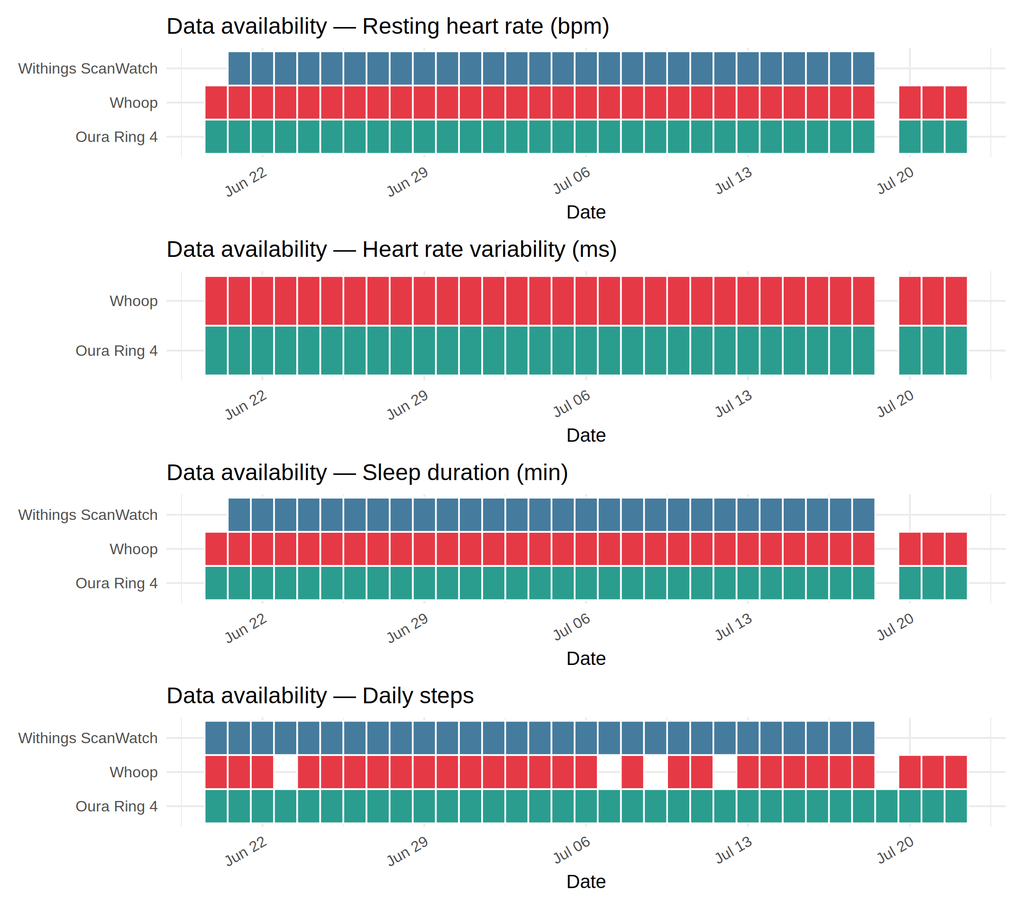

Each colored tile = that device recorded that metric that day. White gaps = missing data, which every comparison skips.

```r
plots <- lapply(METRICS, function(m) plot_overlap_heatmap(overlap, m))
patchwork::wrap_plots(plots, ncol = 1)
```

### 4.1 Quality screening

Two levels of screening run before any comparison:

1. **Hard exclusions** — physiologically impossible values (e.g. heart rate below 30 bpm) are removed.
2. **Soft flags** — suspicious but possible values (e.g. 27 steps in a day, suggesting the device was not worn) are kept but marked, then re-tested later in the sensitivity analysis.

Known issues in this dataset:

- Whoop steps were **typed by hand** into an RTF note, since the app does not export them.
- Withings sleep on **June 20** is corrupt (all stages zero) and is excluded.
- Withings recorded **two sleep sessions on June 26**; the longer one is kept.
- The Withings HRV export is **empty for 2026**.

**Show code that displays the QC exclusion log**

```r
if (nrow(qc_log) > 0) {
  knitr::kable(head(qc_log, 25), caption = "QC exclusions and flags (first 25 rows)")
} else {
  cat("No hard exclusions beyond missing values.")
}
```

QC exclusions and flags (first 25 rows)

| device | metric | date | value | rule | action | source_file |
| --- | --- | --- | --- | --- | --- | --- |
| Whoop | rhr | 2026-07-20 | NA | missing_value | excluded | physiological_cycles.csv |
| Whoop | rhr | 2026-06-20 | NA | missing_value | excluded | physiological_cycles.csv |
| Whoop | rhr_rest | 2026-07-20 | NA | missing_value | excluded | physiological_cycles.csv |
| Whoop | rhr_rest | 2026-06-20 | NA | missing_value | excluded | physiological_cycles.csv |
| Whoop | hrv | 2026-07-20 | NA | missing_value | excluded | physiological_cycles.csv |
| Whoop | hrv | 2026-06-20 | NA | missing_value | excluded | physiological_cycles.csv |
| Whoop | sleep_min | 2026-07-20 | NA | missing_value | excluded | physiological_cycles.csv |
| Whoop | sleep_min | 2026-06-20 | NA | missing_value | excluded | physiological_cycles.csv |
| Whoop | deep_min | 2026-07-20 | NA | missing_value | excluded | physiological_cycles.csv |
| Whoop | deep_min | 2026-06-20 | NA | missing_value | excluded | physiological_cycles.csv |
| Whoop | rem_min | 2026-07-20 | NA | missing_value | excluded | physiological_cycles.csv |
| Whoop | rem_min | 2026-06-20 | NA | missing_value | excluded | physiological_cycles.csv |
| Whoop | light_min | 2026-07-20 | NA | missing_value | excluded | physiological_cycles.csv |
| Whoop | light_min | 2026-06-20 | NA | missing_value | excluded | physiological_cycles.csv |
| Whoop | deep_pct | 2026-07-20 | NA | missing_value | excluded | physiological_cycles.csv |
| Whoop | deep_pct | 2026-06-20 | NA | missing_value | excluded | physiological_cycles.csv |
| Whoop | rem_pct | 2026-07-20 | NA | missing_value | excluded | physiological_cycles.csv |
| Whoop | rem_pct | 2026-06-20 | NA | missing_value | excluded | physiological_cycles.csv |
| Whoop | light_pct | 2026-07-20 | NA | missing_value | excluded | physiological_cycles.csv |
| Whoop | light_pct | 2026-06-20 | NA | missing_value | excluded | physiological_cycles.csv |
| Whoop | awake_min | 2026-07-20 | NA | missing_value | excluded | physiological_cycles.csv |
| Whoop | awake_min | 2026-06-20 | NA | missing_value | excluded | physiological_cycles.csv |
| Whoop | tib_min | 2026-07-20 | NA | missing_value | excluded | physiological_cycles.csv |
| Whoop | tib_min | 2026-06-20 | NA | missing_value | excluded | physiological_cycles.csv |
| Whoop | sleep_eff | 2026-07-20 | NA | missing_value | excluded | physiological_cycles.csv |

## 5 What each device reported

**What this section answers:** *What are the typical values from each device, and how much do they move day to day?*

**Show code that computes summary statistics**

```r
desc_display <- desc_stats |>
  dplyr::filter(metric %in% METRICS) |>
  dplyr::mutate(
    metric = METRIC_LABELS[as.character(metric)],
    dplyr::across(where(is.numeric), ~ round(.x, 2))
  ) |>
  dplyr::select(device, metric, n, mean, sd, median, cv_pct)
knitr::kable(desc_display, caption = "Summary statistics — headline metrics")
```

Summary statistics — headline metrics

| device | metric | n | mean | sd | median | cv_pct |
| --- | --- | --- | --- | --- | --- | --- |
| Whoop | Resting heart rate (bpm) | 32 | 68.84 | 1.67 | 69.00 | 2.42 |
| Whoop | Heart rate variability (ms) | 32 | 31.97 | 3.48 | 32.50 | 10.88 |
| Whoop | Sleep duration (min) | 32 | 448.41 | 56.16 | 447.50 | 12.53 |
| Whoop | Daily steps | 28 | 2727.00 | 2867.20 | 2355.00 | 105.14 |
| Oura Ring 4 | Resting heart rate (bpm) | 32 | 70.44 | 1.63 | 70.40 | 2.31 |
| Oura Ring 4 | Heart rate variability (ms) | 32 | 26.91 | 3.31 | 28.00 | 12.29 |
| Oura Ring 4 | Sleep duration (min) | 32 | 467.03 | 55.03 | 467.25 | 11.78 |
| Oura Ring 4 | Daily steps | 33 | 2498.61 | 2880.41 | 2239.00 | 115.28 |
| Withings ScanWatch | Resting heart rate (bpm) | 28 | 70.57 | 2.56 | 70.00 | 3.63 |
| Withings ScanWatch | Sleep duration (min) | 28 | 503.18 | 50.99 | 496.75 | 10.13 |
| Withings ScanWatch | Daily steps | 29 | 3932.66 | 4506.90 | 2818.00 | 114.60 |

`cv_pct` is the coefficient of variation (SD ÷ mean × 100), a rough stability measure: lower means steadier day to day.

Whoop and Oura sit very close on average resting HR (~69–70 bpm) and HRV (~28–33 ms). Withings’ average sleeping HR has a similar mean but, as the next section shows, it does not follow the same day-to-day pattern.

**Show code that draws ridgeline density plots**

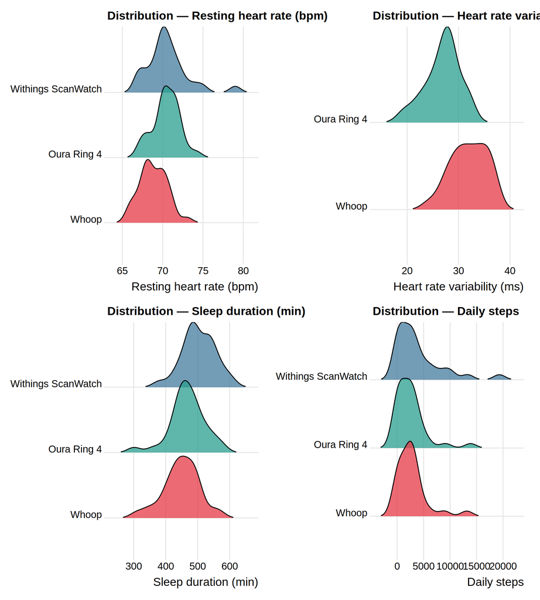

Distribution of daily values. Each band is one device; width shows how often each value occurred. Bands sitting on top of each other = similar distributions.

```r
ridge_plots <- lapply(METRICS, function(m) plot_ridgeline(long_df, m))
patchwork::wrap_plots(ridge_plots, ncol = 2)
```

Note that two devices can produce nearly identical distributions while still disagreeing every single day — matching *overall shape* is a much weaker claim than matching *day by day*. The time series below is the first look at day-by-day behavior.

**Show code that draws time series plots**

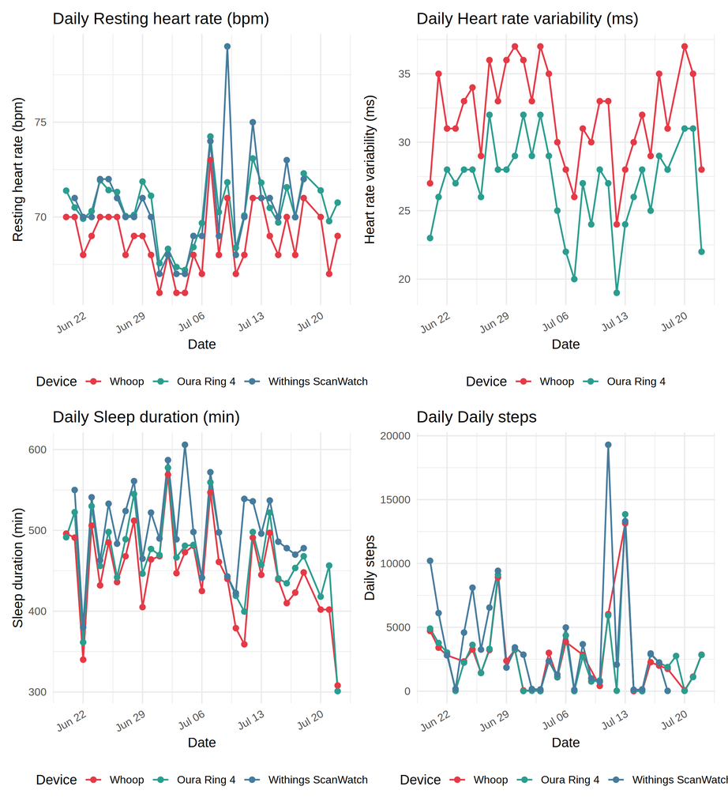

```r
ts_plots <- lapply(METRICS, function(m) plot_timeseries(long_df, m))
patchwork::wrap_plots(ts_plots, ncol = 2)
```

## 6 Pairwise agreement — headline metrics

**What this section answers:** *When two devices both recorded on a day, how closely do their numbers match?*

This section compares devices **two at a time** (Whoop vs Oura, Whoop vs Withings, Oura vs Withings), using every day where that particular pair has data. Note that each pair may therefore rest on a different set of days; the three-device section removes that inconsistency.

| Column | Meaning | Which question it answers |
| --- | --- | --- |
| `pearson_r`, `spearman_rho` | Correlation | Do they move together? |
| `mean_bias` | Average difference (B − A) | Do they report the same number? |
| `loa_lower` / `loa_upper` | 95% limits of agreement | How far apart can they be on a given day? |
| `mae`, `rmse` | Typical error size | How wrong, on average? |
| `srd` | Smallest Real Difference | How big must a gap be to exceed noise? |
| `icc`, `ccc` | Absolute agreement | Are they interchangeable? |
| `deming_slope` / `deming_intercept` | Proportional / fixed bias (ideal: 1 and 0) | Is the disagreement constant or scaling? |

**Show code that runs all pairwise agreement statistics**

```r
if (!is.null(agreement)) {
  agree_display <- agreement |>
    dplyr::mutate(
      metric = METRIC_LABELS[metric],
      dplyr::across(where(is.numeric), ~ round(.x, 3))
    ) |>
    dplyr::select(metric, device_a, device_b, n, pearson_r, spearman_rho,
                  mean_bias, loa_lower, loa_upper, mae, rmse, srd, icc, ccc,
                  deming_slope, deming_intercept)
  knitr::kable(agree_display, caption = "Pairwise agreement — headline metrics")
}
```

Pairwise agreement — headline metrics

| metric | device_a | device_b | n | pearson_r | spearman_rho | mean_bias | loa_lower | loa_upper | mae | rmse | srd | icc | ccc | deming_slope | deming_intercept |
| --- | --- | --- | --- | --- | --- | --- | --- | --- | --- | --- | --- | --- | --- | --- | --- |
| Resting heart rate (bpm) | Whoop | Oura Ring 4 | 32 | 0.914 | 0.920 | 1.598 | 0.259 | 2.938 | 1.598 | 1.734 | 1.340 | 0.623 | NA | 0.973 | 3.423 |
| Resting heart rate (bpm) | Whoop | Withings ScanWatch | 28 | 0.831 | 0.935 | 1.750 | -1.153 | 4.653 | 1.750 | 2.276 | 2.903 | 0.586 | NA | 1.603 | -39.726 |
| Resting heart rate (bpm) | Oura Ring 4 | Withings ScanWatch | 28 | 0.814 | 0.932 | 0.185 | -2.815 | 3.185 | 0.755 | 1.514 | 3.000 | 0.757 | NA | 1.623 | -43.632 |
| Heart rate variability (ms) | Whoop | Oura Ring 4 | 32 | 0.909 | 0.902 | -5.062 | -7.920 | -2.205 | 5.062 | 5.262 | 2.857 | 0.430 | NA | 0.946 | -3.324 |
| Sleep duration (min) | Whoop | Oura Ring 4 | 32 | 0.965 | 0.954 | 18.625 | -10.234 | 47.484 | 19.344 | 23.599 | 28.859 | 0.915 | NA | 0.979 | 28.019 |
| Sleep duration (min) | Whoop | Withings ScanWatch | 28 | 0.767 | 0.815 | 48.143 | -20.047 | 116.332 | 48.143 | 59.033 | 68.190 | 0.534 | NA | 0.999 | 48.447 |
| Sleep duration (min) | Oura Ring 4 | Withings ScanWatch | 28 | 0.785 | 0.793 | 28.964 | -34.811 | 92.740 | 28.964 | 43.126 | 63.776 | 0.673 | NA | 1.085 | -11.397 |
| Daily steps | Whoop | Oura Ring 4 | 28 | 0.996 | 0.969 | 89.571 | -488.083 | 667.226 | 211.929 | 302.955 | 577.655 | 0.995 | NA | 1.043 | -26.649 |
| Daily steps | Whoop | Withings ScanWatch | 25 | 0.785 | 0.886 | 1535.320 | -4287.991 | 7358.631 | 1766.840 | 3291.111 | 5823.311 | 0.667 | NA | 1.758 | -657.135 |
| Daily steps | Oura Ring 4 | Withings ScanWatch | 29 | 0.794 | 0.861 | 1321.759 | -4156.743 | 6800.260 | 1509.759 | 3048.036 | 5478.501 | 0.700 | NA | 1.638 | -344.281 |

**Show code that draws the correlation heatmap**

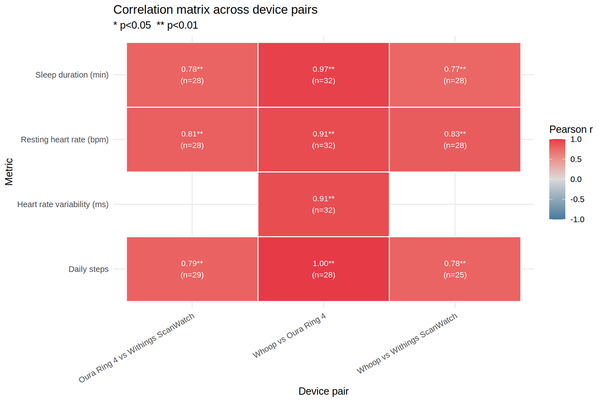

Pearson r for every metric and device pair. Red = positive correlation, gray = none, blue = negative. * = p<0.05, ** = p<0.01.

```r
if (!is.null(agreement)) plot_correlation_heatmap(agreement)
```

**Interpretation:** Whoop–Oura exceed r = 0.9 on all four headline metrics. Pairs involving Withings are consistently weaker, and the resting-HR gap has a specific, fixable cause — covered next.

### 6.1 Is the difference small enough to ignore?

**What this section answers:** *Correlation aside, is the average gap between devices too big to matter in practice?*

A significant p-value only says a difference exists; it does not say the difference is *important*. So each pair is checked against a margin set in advance from what a user could actually act on — for example, a 2 bpm resting-HR offset falls within normal day-to-day noise and would not change any decision.

A pair is marked **equivalent** only when the entire 95% confidence interval of its bias fits inside that margin.

**Show code that runs the equivalence check**

```r
if (!is.null(agreement)) {
  knitr::kable(
    agreement |>
      dplyr::mutate(
        metric = METRIC_LABELS[metric],
        bias = round(mean_bias, 2),
        ci = sprintf("[%.2f, %.2f]", bias_ci_lower, bias_ci_upper),
        margin = sprintf("+/- %g", equiv_margin),
        srd = round(srd, 1)
      ) |>
      dplyr::select(metric, device_a, device_b, n, bias, ci, margin,
                    equivalent, srd),
    caption = "Equivalence check: is the bias inside a practically acceptable margin?"
  )
}
```

Equivalence check: is the bias inside a practically acceptable margin?

| metric | device_a | device_b | n | bias | ci | margin | equivalent | srd |
| --- | --- | --- | --- | --- | --- | --- | --- | --- |
| Resting heart rate (bpm) | Whoop | Oura Ring 4 | 32 | 1.60 | [1.35, 1.84] | +/- 2 | Yes | 1.3 |
| Resting heart rate (bpm) | Whoop | Withings ScanWatch | 28 | 1.75 | [1.18, 2.32] | +/- 2 | No | 2.9 |
| Resting heart rate (bpm) | Oura Ring 4 | Withings ScanWatch | 28 | 0.18 | [-0.41, 0.78] | +/- 2 | Yes | 3.0 |
| Heart rate variability (ms) | Whoop | Oura Ring 4 | 32 | -5.06 | [-5.59, -4.54] | +/- 5 | No | 2.9 |
| Sleep duration (min) | Whoop | Oura Ring 4 | 32 | 18.62 | [13.32, 23.93] | +/- 30 | Yes | 28.9 |
| Sleep duration (min) | Whoop | Withings ScanWatch | 28 | 48.14 | [34.65, 61.63] | +/- 30 | No | 68.2 |
| Sleep duration (min) | Oura Ring 4 | Withings ScanWatch | 28 | 28.96 | [16.35, 41.58] | +/- 30 | No | 63.8 |
| Daily steps | Whoop | Oura Ring 4 | 28 | 89.57 | [-24.71, 203.85] | +/- 1000 | Yes | 577.7 |
| Daily steps | Whoop | Withings ScanWatch | 25 | 1535.32 | [308.92, 2761.72] | +/- 1000 | No | 5823.3 |
| Daily steps | Oura Ring 4 | Withings ScanWatch | 29 | 1321.76 | [258.54, 2384.98] | +/- 1000 | No | 5478.5 |

**How to read it:** `equivalent = Yes` means the two devices can reasonably stand in for each other on that metric. `No` means they cannot, even if their correlation is high. The `srd` column is a useful companion: for sleep duration it runs to roughly an hour, so a 20-minute difference between two devices carries no real information.

### 6.2 Resting HR — the definition matters more than the sensor

**What this section answers:** *Is Withings’ weak resting-HR agreement a hardware problem or a definition mismatch?*

The three devices do not mean the same thing by “resting heart rate”:

| Device | Used as `rhr` | Used as `rhr_rest` (like-for-like) |
| --- | --- | --- |
| Whoop | Recovery RHR (lowest during sleep) | Same |
| Oura | **Average** resting HR | **Lowest** resting HR |
| Withings | **Average** HR during sleep | **Minimum** HR during sleep |

Comparing the `rhr` column pits Whoop’s true resting value against Withings’ whole-night average — an apples-to-oranges comparison. The `rhr_rest` column re-runs the analysis with all three harmonized to their lowest value.

**Show code that compares RHR using the harmonized definition**

```r
rhr_rest_agree <- run_all_agreement(wide_df, metrics = "rhr_rest")
if (!is.null(rhr_rest_agree)) {
  knitr::kable(
    rhr_rest_agree |>
      dplyr::mutate(
        metric = "Resting HR (like-for-like)",
        dplyr::across(where(is.numeric), ~ round(.x, 3))
      ) |>
      dplyr::select(metric, device_a, device_b, n, pearson_r, mean_bias,
                    loa_lower, loa_upper, icc, ccc, equivalent),
    caption = "RHR agreement using the harmonized 'lowest value' definition"
  )
}
```

RHR agreement using the harmonized ‘lowest value’ definition

| metric | device_a | device_b | n | pearson_r | mean_bias | loa_lower | loa_upper | icc | ccc | equivalent |
| --- | --- | --- | --- | --- | --- | --- | --- | --- | --- | --- |
| Resting HR (like-for-like) | Whoop | Oura Ring 4 | 32 | 0.735 | -6.344 | -9.477 | -3.211 | 0.119 | NA | No |
| Resting HR (like-for-like) | Whoop | Withings ScanWatch | 28 | 0.758 | -6.786 | -9.958 | -3.614 | 0.117 | NA | No |
| Resting HR (like-for-like) | Oura Ring 4 | Withings ScanWatch | 28 | 0.942 | -0.393 | -2.023 | 1.237 | 0.930 | NA | Yes |

**Result — and it is not the result you might expect.** Harmonizing the definition does not lift every pair; it *rearranges* which pairs agree:

| Pair | `rhr` (as shipped) | `rhr_rest` (lowest value) |
| --- | --- | --- |
| Whoop vs Oura | r = 0.91 | r = 0.74 |
| Whoop vs Withings | r = 0.83 | r = 0.76 |
| **Oura vs Withings** | r = 0.81 | **r = 0.94**, ICC = 0.93, bias = −0.4 bpm |

The explanation is that Whoop publishes only one resting-HR number, so its column is identical in both rows. Whoop’s “recovery RHR” therefore behaves statistically more like Oura’s and Withings’ **averages** than like their **minima**, despite being documented as a sleeping low. Read literally, the labels imply the wrong grouping.

This is the clearest demonstration in the report that a metric name is not a definition. Before concluding that a device is inaccurate, check that it was asked the same question as the others.

### 6.3 How to read the scatter and Bland–Altman plots

Each metric below gets two plot types per device pair.

**Scatter plot (left):**

- Each dot is one day where both devices recorded.
- Dashed diagonal = perfect agreement.
- Solid colored line = Deming regression, which allows for error in both devices.
- Dots hugging the diagonal = good agreement.

**Bland–Altman plot (right):**

- X-axis = the average of the two readings that day; Y-axis = their difference.
- Solid line = mean bias; shaded band and dashed lines = 95% limits of agreement.
- Randomly scattered points around zero = good agreement.
- A visible slope across the x-axis = **proportional bias**: the devices disagree more at high values than at low ones.

**Show code that draws RHR scatter and Bland–Altman plots**

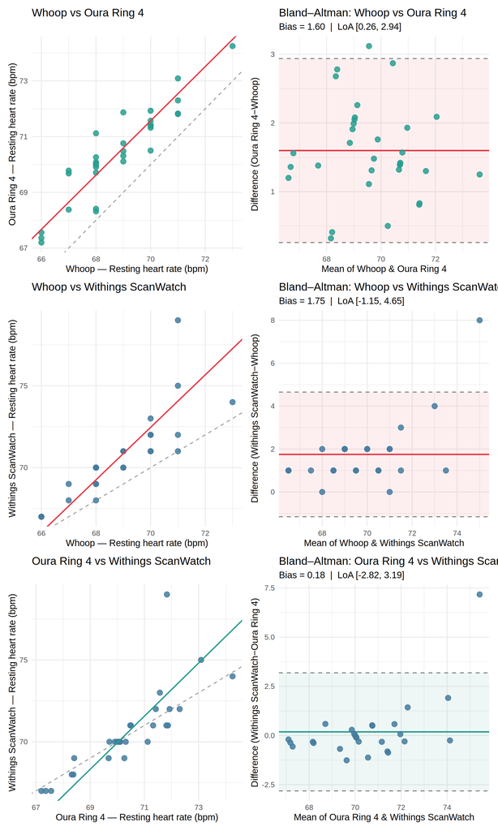

Resting HR: scatter with Deming line (left) and Bland-Altman (right) for all three device pairs.

```r
rhr_pairs <- list(
  c("whoop", "oura", "Whoop", "Oura Ring 4"),
  c("whoop", "withings", "Whoop", "Withings ScanWatch"),
  c("oura", "withings", "Oura Ring 4", "Withings ScanWatch")
)
rhr_plots <- unlist(lapply(rhr_pairs, function(p) list(
  plot_scatter_pair(wide_df, "rhr", p[1], p[2], p[3], p[4]),
  plot_bland_altman(wide_df, "rhr", p[1], p[2], p[3], p[4])
)), recursive = FALSE)
patchwork::wrap_plots(Filter(Negate(is.null), rhr_plots), ncol = 2)
```

All three pairs are shown here rather than a selected subset, so the Oura–Withings comparison is not hidden.

**Show code that draws sleep scatter and Bland–Altman plots**

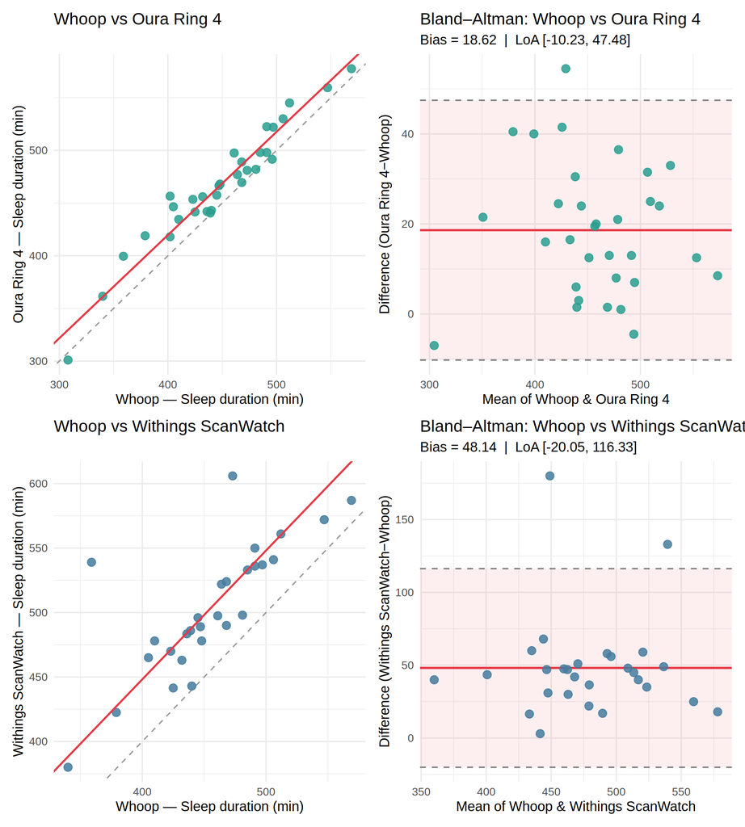

Sleep duration (minutes): scatter and Bland-Altman. Note how much wider the limits of agreement are than for resting HR.

```r
sleep_plots <- list(
  plot_scatter_pair(wide_df, "sleep_min", "whoop", "oura", "Whoop", "Oura Ring 4"),
  plot_bland_altman(wide_df, "sleep_min", "whoop", "oura", "Whoop", "Oura Ring 4"),
  plot_scatter_pair(wide_df, "sleep_min", "whoop", "withings", "Whoop", "Withings ScanWatch"),
  plot_bland_altman(wide_df, "sleep_min", "whoop", "withings", "Whoop", "Withings ScanWatch")
)
patchwork::wrap_plots(Filter(Negate(is.null), sleep_plots), ncol = 2)
```

**Show code that draws steps scatter and Bland–Altman plots**

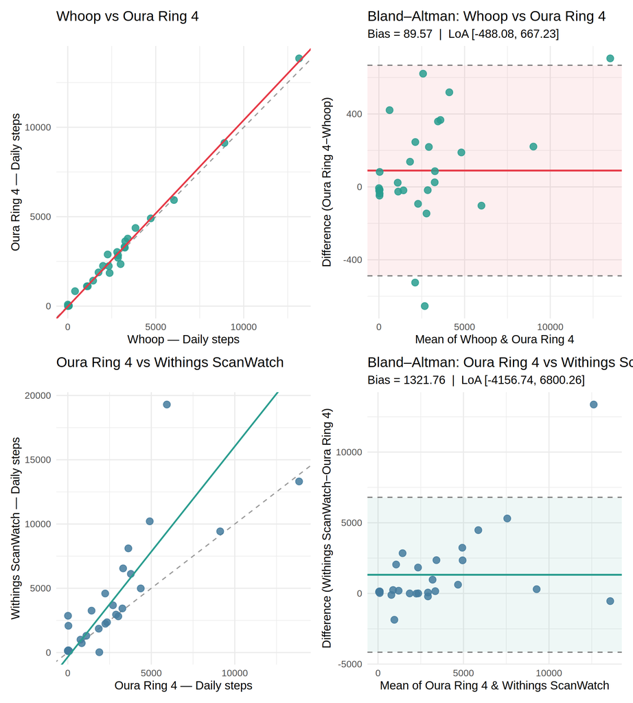

Daily steps: scatter and Bland-Altman. Whoop steps were logged by hand, so treat that pair with extra caution.

```r
step_plots <- list(
  plot_scatter_pair(wide_df, "steps", "whoop", "oura", "Whoop", "Oura Ring 4"),
  plot_bland_altman(wide_df, "steps", "whoop", "oura", "Whoop", "Oura Ring 4"),
  plot_scatter_pair(wide_df, "steps", "oura", "withings", "Oura Ring 4", "Withings ScanWatch"),
  plot_bland_altman(wide_df, "steps", "oura", "withings", "Oura Ring 4", "Withings ScanWatch")
)
patchwork::wrap_plots(Filter(Negate(is.null), step_plots), ncol = 2)
```

**Show code that draws HRV scatter and Bland–Altman plots**

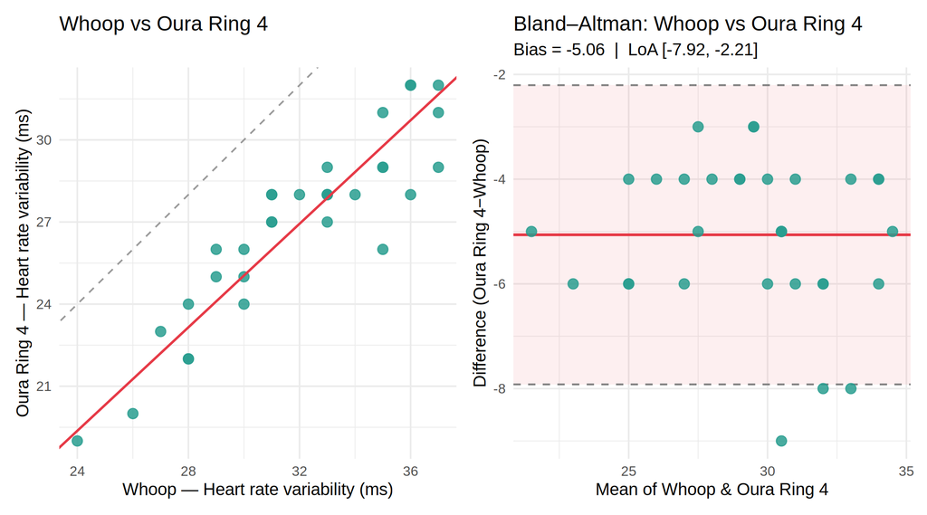

HRV (milliseconds): Whoop vs Oura only — Withings exported no HRV for 2026.

```r
hrv_plots <- list(
  plot_scatter_pair(wide_df, "hrv", "whoop", "oura", "Whoop", "Oura Ring 4"),
  plot_bland_altman(wide_df, "hrv", "whoop", "oura", "Whoop", "Oura Ring 4")
)
patchwork::wrap_plots(Filter(Negate(is.null), hrv_plots), ncol = 2)
```

### 6.4 Does the disagreement grow at higher values?

**What this section answers:** *Is the gap between devices constant, or does it scale with the size of the reading?*

A constant offset is easy to live with — you can mentally subtract it. A gap that *grows* with the value is worse, because no single correction fixes it. The test below correlates each day’s difference with that day’s average: a significant result means proportional bias.

**Show code that tests for proportional bias**

```r
if (!is.null(agreement)) {
  knitr::kable(
    agreement |>
      dplyr::mutate(
        metric = METRIC_LABELS[metric],
        ba_trend_r = round(ba_trend_r, 3),
        ba_trend_p = fmt_p(ba_trend_p),
        deming_slope = round(deming_slope, 3),
        verdict = dplyr::if_else(
          !is.na(ba_trend_p) & ba_trend_p < 0.05,
          "Proportional bias present",
          "Constant offset only"
        )
      ) |>
      dplyr::select(metric, device_a, device_b, n, ba_trend_r, ba_trend_p,
                    deming_slope, verdict),
    caption = "Proportional-bias test: does the difference between devices scale with the value?"
  )
}
```

Proportional-bias test: does the difference between devices scale with the value?

| metric | device_a | device_b | n | ba_trend_r | ba_trend_p | deming_slope | verdict |
| --- | --- | --- | --- | --- | --- | --- | --- |
| Resting heart rate (bpm) | Whoop | Oura Ring 4 | 32 | -0.061 | 0.742 | 0.973 | Constant offset only |
| Resting heart rate (bpm) | Whoop | Withings ScanWatch | 28 | 0.589 | <0.001 | 1.603 | Proportional bias present |
| Resting heart rate (bpm) | Oura Ring 4 | Withings ScanWatch | 28 | 0.576 | 0.001 | 1.623 | Proportional bias present |
| Heart rate variability (ms) | Whoop | Oura Ring 4 | 32 | -0.121 | 0.509 | 0.946 | Constant offset only |
| Sleep duration (min) | Whoop | Oura Ring 4 | 32 | -0.078 | 0.672 | 0.979 | Constant offset only |
| Sleep duration (min) | Whoop | Withings ScanWatch | 28 | -0.001 | 0.997 | 0.999 | Constant offset only |
| Sleep duration (min) | Oura Ring 4 | Withings ScanWatch | 28 | 0.103 | 0.602 | 1.085 | Constant offset only |
| Daily steps | Whoop | Oura Ring 4 | 28 | 0.413 | 0.029 | 1.043 | Proportional bias present |
| Daily steps | Whoop | Withings ScanWatch | 25 | 0.602 | 0.001 | 1.758 | Proportional bias present |
| Daily steps | Oura Ring 4 | Withings ScanWatch | 29 | 0.557 | 0.002 | 1.638 | Proportional bias present |

### 6.5 Is agreement stable over the 33 days?

A single correlation for the whole window can hide a device that drifted. These two views check for that.

**Show code that plots daily differences over time**

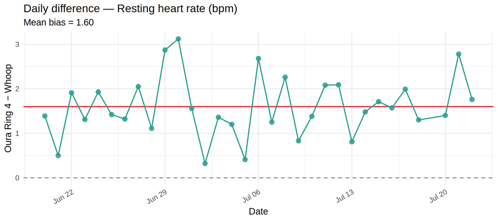

Daily resting-HR difference (Oura minus Whoop). A flat line near zero = stable agreement; a trend = one device drifting.

```r
plot_difference_timeseries(wide_df, "rhr", "whoop", "oura", "Whoop", "Oura Ring 4")
```

**Show code that computes rolling correlation**

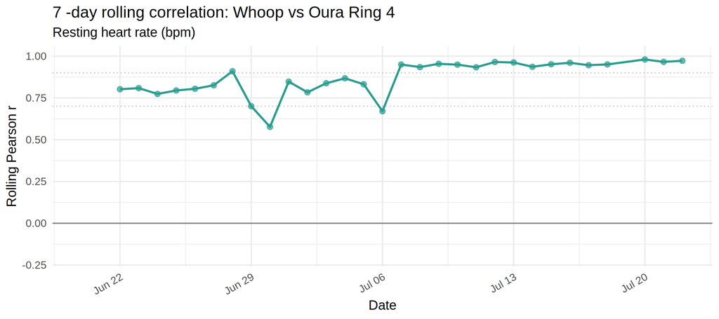

7-day rolling Pearson r for resting HR (Whoop vs Oura). Values near 1.0 mean the two devices agreed closely that week.

```r
plot_rolling_correlation(wide_df, "rhr", "whoop", "oura", "Whoop", "Oura Ring 4")
```

## 7 Three-device tests (all methods together)

**What this section answers:** *On days when all three devices recorded, do they agree as a set?*

The pairwise tables above compare two devices at a time, and each pair can rest on a different set of days. That can conceal a three-way mismatch: Whoop and Oura may agree across 32 days while Withings only overlaps 28 of them.

Here only days where **all three** devices have a value are kept, and the three methods are then tested as a single group:

| Test | Question it answers | How to read it |
| --- | --- | --- |
| **Three-rater ICC(2,1)** | Would three readings of a random day be interchangeable? | Near **1** = yes; below **0.5** = poor. The 95% CI shows how precisely ICC is known. |
| **OCCC** | Lin’s CCC extended to three devices | Near **1** = they track each other *and* sit at the same level. |
| **Kendall’s W** | Do all three rank days in the same order? | **1** = identical ranking. |
| **Friedman’s test** | Do the three sit at different levels? | Small p = at least one reads systematically high or low. |
| **RM-ANOVA** | Same question, using means | Same reading as Friedman; assumes roughly normal values. |
| **max_mean_gap** | Largest gap between any two device averages | The practical size of the disagreement, in the metric’s own units. |

Two statistics were deliberately **left out**: Cronbach’s α and the ICC F-test p-value. Both are dominated by how much values vary between days, so they stay near 1 (or produce a tiny p-value) even when two devices differ by a large constant offset — exactly the situation a reader would want flagged.

**HRV is absent** from this section: with no Withings HRV, a three-device HRV test is impossible.

**Show code that runs simultaneous three-device agreement tests**

```r
if (!is.null(threeway_tbl) && nrow(threeway_tbl) > 0) {
  knitr::kable(
    threeway_tbl |>
      dplyr::mutate(
        metric = METRIC_LABELS[metric],
        icc = round(icc, 3),
        icc_95 = sprintf("[%.2f, %.2f]", icc_lbound, icc_ubound),
        occc = round(occc, 3),
        kendall_w = round(kendall_w, 3),
        kendall_p = fmt_p(kendall_p),
        max_mean_gap = round(max_mean_gap, 1)
      ) |>
      dplyr::select(metric, n_days, icc, icc_95, occc, kendall_w, kendall_p,
                    max_mean_gap),
    caption = "Three-device agreement on complete-case days"
  )
}
```

Three-device agreement on complete-case days

| metric | n_days | icc | icc_95 | occc | kendall_w | kendall_p | max_mean_gap |
| --- | --- | --- | --- | --- | --- | --- | --- |
| Resting heart rate (bpm) | 28 | 0.657 | [0.27, 0.85] | 0.653 | 0.953 | <0.001 | 1.8 |
| Resting HR, like-for-like (bpm) | 28 | 0.200 | [-0.01, 0.50] | 0.200 | 0.879 | <0.001 | 6.8 |
| Sleep duration (min) | 28 | 0.682 | [0.24, 0.87] | 0.678 | 0.905 | <0.001 | 48.1 |
| Daily steps | 25 | 0.743 | [0.55, 0.87] | 0.737 | 0.939 | <0.001 | 1535.3 |
| Deep sleep (min) | 26 | 0.039 | [-0.03, 0.17] | 0.039 | 0.503 | 0.049 | 129.0 |
| REM sleep (min) | 28 | 0.026 | [-0.03, 0.12] | 0.025 | 0.390 | 0.246 | 81.1 |
| Light sleep (min) | 28 | 0.509 | [0.28, 0.71] | 0.501 | 0.630 | 0.003 | 29.0 |
| Deep sleep (% of sleep) | 28 | 0.048 | [-0.03, 0.18] | 0.047 | 0.501 | 0.045 | 26.1 |
| REM sleep (% of sleep) | 28 | 0.019 | [-0.03, 0.10] | 0.019 | 0.395 | 0.232 | 17.0 |
| Light sleep (% of sleep) | 28 | 0.159 | [-0.02, 0.39] | 0.156 | 0.538 | 0.023 | 9.9 |
| Awake time during sleep (min) | 28 | 0.267 | [0.01, 0.54] | 0.265 | 0.636 | 0.003 | 29.5 |
| Time in bed (min) | 28 | 0.613 | [0.40, 0.78] | 0.606 | 0.821 | <0.001 | 27.9 |
| Sleep efficiency (%) | 28 | 0.160 | [-0.03, 0.40] | 0.156 | 0.625 | 0.004 | 5.2 |
| Bedtime (hours after noon) | 28 | 0.984 | [0.94, 0.99] | 0.984 | 0.986 | <0.001 | 0.1 |
| Wake time (hours after midnight) | 28 | 0.636 | [0.43, 0.80] | 0.630 | 0.848 | <0.001 | 0.5 |

**How to read it:** `n_days` is the number of mornings all three devices recorded. ICC, OCCC and W all run 0–1, higher being more interchangeable. The revealing pattern is **high W with low ICC**: the devices rank days the same way but sit at different levels. Sleep staging is the clearest case — and bedtime is the opposite, with near-perfect agreement on both counts.

**Show code that tests whether the three devices sit at different levels**

```r
if (!is.null(threeway_tbl) && nrow(threeway_tbl) > 0) {
  knitr::kable(
    threeway_tbl |>
      dplyr::mutate(
        metric = METRIC_LABELS[metric],
        friedman_chi2 = round(friedman_chi2, 2),
        differ = dplyr::if_else(
          !is.na(friedman_p) & friedman_p < 0.05,
          "Yes — at least one device differs",
          "No significant level difference"
        ),
        friedman_p = fmt_p(friedman_p),
        anova_f = round(anova_f, 2),
        anova_p = fmt_p(anova_p)
      ) |>
      dplyr::select(metric, n_days, friedman_chi2, friedman_p, anova_f, anova_p, differ),
    caption = "Do the three devices sit at the same level? Friedman rank test and repeated-measures ANOVA"
  )
}
```

Do the three devices sit at the same level? Friedman rank test and repeated-measures ANOVA

| metric | n_days | friedman_chi2 | friedman_p | anova_f | anova_p | differ |
| --- | --- | --- | --- | --- | --- | --- |
| Resting heart rate (bpm) | 28 | 40.65 | <0.001 | 30.95 | <0.001 | Yes — at least one device differs |
| Resting HR, like-for-like (bpm) | 28 | 50.55 | <0.001 | 411.22 | <0.001 | Yes — at least one device differs |
| Sleep duration (min) | 28 | 54.62 | <0.001 | 40.68 | <0.001 | Yes — at least one device differs |
| Daily steps | 25 | 18.32 | <0.001 | 6.19 | 0.004 | Yes — at least one device differs |
| Deep sleep (min) | 26 | 26.20 | <0.001 | 63.70 | <0.001 | Yes — at least one device differs |
| REM sleep (min) | 28 | 38.88 | <0.001 | 102.82 | <0.001 | Yes — at least one device differs |
| Light sleep (min) | 28 | 7.39 | 0.025 | 5.54 | 0.007 | Yes — at least one device differs |
| Deep sleep (% of sleep) | 28 | 29.85 | <0.001 | 69.90 | <0.001 | Yes — at least one device differs |
| REM sleep (% of sleep) | 28 | 38.88 | <0.001 | 111.39 | <0.001 | Yes — at least one device differs |
| Light sleep (% of sleep) | 28 | 13.60 | 0.001 | 14.75 | <0.001 | Yes — at least one device differs |
| Awake time during sleep (min) | 28 | 31.15 | <0.001 | 46.87 | <0.001 | Yes — at least one device differs |
| Time in bed (min) | 28 | 31.15 | <0.001 | 4.85 | 0.012 | Yes — at least one device differs |
| Sleep efficiency (%) | 28 | 34.98 | <0.001 | 7.90 | <0.001 | Yes — at least one device differs |
| Bedtime (hours after noon) | 28 | 33.14 | <0.001 | 23.96 | <0.001 | Yes — at least one device differs |
| Wake time (hours after midnight) | 28 | 39.93 | <0.001 | 6.01 | 0.004 | Yes — at least one device differs |

When Friedman is significant, the post-hoc table identifies **which** pair is responsible. These are Wilcoxon signed-rank tests on the same complete-case days, Bonferroni-adjusted for three comparisons; `median_diff` is device B minus device A.

**Show code that runs Bonferroni Wilcoxon post-hoc tests**

```r
headline_threeway <- c("rhr", "rhr_rest", "sleep_min", "steps")
if (!is.null(threeway_post) && nrow(threeway_post) > 0) {
  knitr::kable(
    threeway_post |>
      dplyr::filter(metric %in% headline_threeway) |>
      dplyr::mutate(
        metric = METRIC_LABELS[metric],
        median_diff = round(median_diff, 2),
        wilcox_p_raw = fmt_p(wilcox_p_raw),
        wilcox_p_bonferroni = fmt_p(wilcox_p_bonferroni)
      ),
    caption = "Post-hoc: which device pair differs on complete-case days (Bonferroni-adjusted Wilcoxon)"
  )
}
```

Post-hoc: which device pair differs on complete-case days (Bonferroni-adjusted Wilcoxon)

| metric | device_a | device_b | n_days | median_diff | wilcox_p_raw | wilcox_p_bonferroni |
| --- | --- | --- | --- | --- | --- | --- |
| Resting heart rate (bpm) | Whoop | Oura Ring 4 | 28 | 1.45 | <0.001 | <0.001 |
| Resting heart rate (bpm) | Whoop | Withings ScanWatch | 28 | 1.50 | <0.001 | <0.001 |
| Resting heart rate (bpm) | Oura Ring 4 | Withings ScanWatch | 28 | -0.16 | 0.473 | 1.000 |
| Resting HR, like-for-like (bpm) | Whoop | Oura Ring 4 | 28 | -6.00 | <0.001 | <0.001 |
| Resting HR, like-for-like (bpm) | Whoop | Withings ScanWatch | 28 | -6.50 | <0.001 | <0.001 |
| Resting HR, like-for-like (bpm) | Oura Ring 4 | Withings ScanWatch | 28 | 0.00 | 0.024 | 0.073 |
| Sleep duration (min) | Whoop | Oura Ring 4 | 28 | 19.75 | <0.001 | <0.001 |
| Sleep duration (min) | Whoop | Withings ScanWatch | 28 | 44.25 | <0.001 | <0.001 |
| Sleep duration (min) | Oura Ring 4 | Withings ScanWatch | 28 | 18.50 | <0.001 | <0.001 |
| Daily steps | Whoop | Oura Ring 4 | 25 | 82.00 | 0.080 | 0.241 |
| Daily steps | Whoop | Withings ScanWatch | 25 | 316.00 | 0.001 | 0.003 |
| Daily steps | Oura Ring 4 | Withings ScanWatch | 25 | 161.00 | 0.003 | 0.010 |

**Show code that draws three-device complete-case plots**

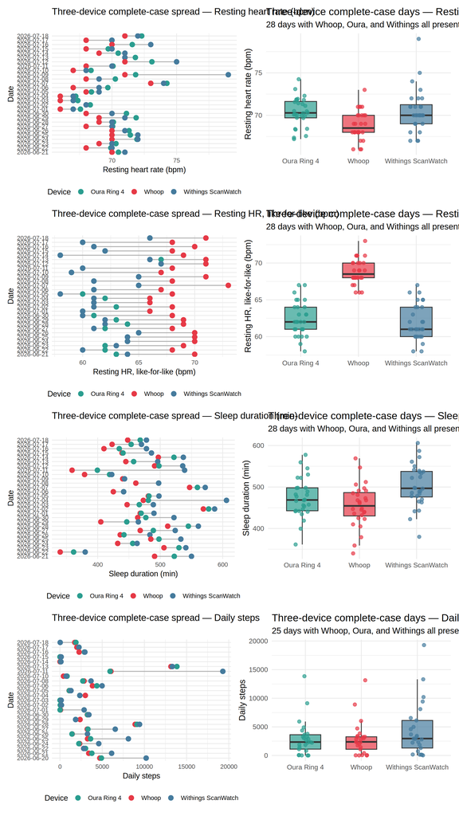

Complete-case days only. Left: each row is one day, with the three readings connected — a long gray line means the devices disagreed that day. Right: the same days as boxplots.

```r
threeway_metrics <- c("rhr", "rhr_rest", "sleep_min", "steps")
tw_plots <- lapply(threeway_metrics, function(m) {
  left  <- plot_paired_dumbbell(wide_df, m, complete_only = TRUE)
  right <- plot_threeway_box(wide_df, m)
  if (is.null(left) || is.null(right)) return(NULL)
  patchwork::wrap_plots(list(left, right), ncol = 2)
})
tw_plots <- Filter(Negate(is.null), tw_plots)
if (length(tw_plots) > 0) patchwork::wrap_plots(tw_plots, ncol = 1)
```

## 8 Sleep architecture (stage comparison)

**What this section answers:** *Do the devices agree on how the night was divided into deep, REM, and light sleep?*

Total sleep time can agree well even when devices disagree completely about *structure* — one calling a stretch “deep” while another calls it “light”. Three stages are compared:

- **Deep sleep** — physically restorative, hard to wake from.
- **REM sleep** — the dreaming stage, tied to memory and mood.
- **Light sleep** — transitional, and the largest share for most people.

### 8.1 Stage composition (the fair comparison)

Comparing stage *minutes* confounds two different things: how a device splits stages, and how much total sleep it recorded. A device that logs 30 minutes less sleep will report fewer deep-sleep minutes even with an identical staging algorithm. Converting each stage to a **share of that night’s total sleep** isolates the algorithm.

**Show code that draws the stage composition chart**

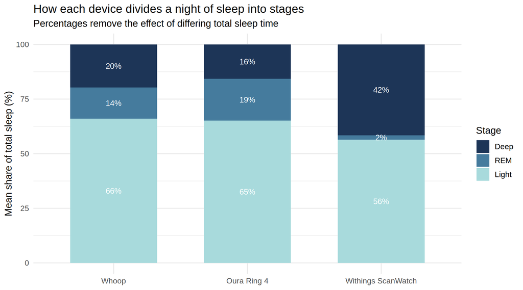

Mean share of the night assigned to each stage. Percentages remove the effect of differing total sleep time.

```r
plot_stage_composition(long_df)
```

**This is the largest disagreement anywhere in the report.** Withings assigns roughly **40%** of the night to deep sleep, against 16–20% for Whoop and Oura, and it detects almost **no REM** (~2% versus 14–19%). A hybrid watch measuring from the wrist simply does not separate REM the way a ring or strap does. Any Withings deep- or REM-sleep number should be treated as a different quantity, not a noisier version of the same one.

**Show code that computes stage-percentage agreement**

```r
stage_pct_agree <- run_all_agreement(wide_df, metrics = SLEEP_STAGE_PCT_METRICS)
if (!is.null(stage_pct_agree)) {
  knitr::kable(
    stage_pct_agree |>
      dplyr::mutate(
        metric = METRIC_LABELS[metric],
        dplyr::across(where(is.numeric), ~ round(.x, 2))
      ) |>
      dplyr::select(metric, device_a, device_b, n, pearson_r, mean_bias,
                    loa_lower, loa_upper, icc, equivalent),
    caption = "Stage agreement as a percentage of total sleep"
  )
}
```

Stage agreement as a percentage of total sleep

| metric | device_a | device_b | n | pearson_r | mean_bias | loa_lower | loa_upper | icc | equivalent |
| --- | --- | --- | --- | --- | --- | --- | --- | --- | --- |
| Deep sleep (% of sleep) | Whoop | Oura Ring 4 | 32 | 0.52 | -4.00 | -11.93 | 3.94 | 0.36 | No |
| Deep sleep (% of sleep) | Whoop | Withings ScanWatch | 28 | 0.25 | 22.19 | -7.54 | 51.92 | 0.04 | No |
| Deep sleep (% of sleep) | Oura Ring 4 | Withings ScanWatch | 28 | 0.26 | 26.09 | -3.53 | 55.71 | 0.04 | No |
| REM sleep (% of sleep) | Whoop | Oura Ring 4 | 32 | 0.42 | 4.85 | -4.00 | 13.70 | 0.25 | No |
| REM sleep (% of sleep) | Whoop | Withings ScanWatch | 28 | 0.05 | -12.28 | -26.53 | 1.97 | 0.01 | No |
| REM sleep (% of sleep) | Oura Ring 4 | Withings ScanWatch | 28 | 0.13 | -16.97 | -29.60 | -4.35 | 0.01 | No |
| Light sleep (% of sleep) | Whoop | Oura Ring 4 | 32 | 0.42 | -0.85 | -11.62 | 9.91 | 0.42 | Yes |
| Light sleep (% of sleep) | Whoop | Withings ScanWatch | 28 | 0.30 | -9.91 | -34.67 | 14.85 | 0.15 | No |
| Light sleep (% of sleep) | Oura Ring 4 | Withings ScanWatch | 28 | 0.33 | -9.12 | -33.44 | 15.20 | 0.14 | No |

Even between Whoop and Oura — the closest pair everywhere else — stage percentages correlate only around r = 0.4–0.5. Staging is the hardest problem in consumer sleep tracking, and it is where these devices are least substitutable.

**Show code that computes sleep-stage agreement in minutes**

```r
stage_agree <- run_all_agreement(wide_df, metrics = SLEEP_STAGE_METRICS)
if (!is.null(stage_agree)) {
  knitr::kable(
    stage_agree |>
      dplyr::mutate(
        metric = METRIC_LABELS[metric],
        dplyr::across(where(is.numeric), ~ round(.x, 2))
      ) |>
      dplyr::select(metric, device_a, device_b, n, pearson_r, mean_bias,
                    loa_lower, loa_upper, icc, srd),
    caption = "Sleep-stage agreement in absolute minutes (for reference)"
  )
}
```

Sleep-stage agreement in absolute minutes (for reference)

| metric | device_a | device_b | n | pearson_r | mean_bias | loa_lower | loa_upper | icc | srd |
| --- | --- | --- | --- | --- | --- | --- | --- | --- | --- |
| Deep sleep (min) | Whoop | Oura Ring 4 | 32 | 0.42 | -14.72 | -50.42 | 20.98 | 0.31 | 35.70 |
| Deep sleep (min) | Whoop | Withings ScanWatch | 26 | 0.31 | 114.02 | -35.61 | 263.65 | 0.04 | 149.63 |
| Deep sleep (min) | Oura Ring 4 | Withings ScanWatch | 26 | 0.25 | 129.04 | -22.61 | 280.69 | 0.03 | 151.65 |
| REM sleep (min) | Whoop | Oura Ring 4 | 32 | 0.48 | 25.77 | -17.39 | 68.93 | 0.29 | 43.16 |
| REM sleep (min) | Whoop | Withings ScanWatch | 28 | 0.01 | -55.84 | -124.66 | 12.98 | 0.00 | 68.82 |
| REM sleep (min) | Oura Ring 4 | Withings ScanWatch | 28 | 0.07 | -81.14 | -145.85 | -16.43 | 0.01 | 64.71 |
| Light sleep (min) | Whoop | Oura Ring 4 | 32 | 0.85 | 7.58 | -43.36 | 58.51 | 0.84 | 50.93 |
| Light sleep (min) | Whoop | Withings ScanWatch | 28 | 0.48 | -20.68 | -132.79 | 91.43 | 0.44 | 112.11 |
| Light sleep (min) | Oura Ring 4 | Withings ScanWatch | 28 | 0.55 | -29.00 | -131.53 | 73.52 | 0.43 | 102.52 |

**Show code that draws sleep architecture stacked bars**

[figure not shown]

```r
plot_sleep_architecture(arch_df, n_nights = 14)
```

## 9 Sleep timing, awake time, and time in bed

**What this section answers:** *Do the devices agree on when sleep started and ended, and on how much of the night was spent awake?*

These are the mechanical building blocks of sleep tracking: a device must first detect the boundaries of the night, then decide how much of it counted as sleep. Splitting those apart shows exactly where sleep-duration differences come from.

Timing uses decimal hours:

- **Bedtime** = hours after noon (13.5 = 1:30 am).
- **Wake time** = hours after midnight (7.8 = 7:48 am).

**Show code that compares bedtime, wake time, awake time, and time in bed**

```r
timing_agree <- run_all_agreement(
  wide_df, metrics = c("bedtime_hr", "waketime_hr", "tib_min", "awake_min")
)
if (!is.null(timing_agree)) {
  knitr::kable(
    timing_agree |>
      dplyr::mutate(
        metric = METRIC_LABELS[metric],
        dplyr::across(where(is.numeric), ~ round(.x, 2))
      ) |>
      dplyr::select(metric, device_a, device_b, n, pearson_r, mean_bias,
                    loa_lower, loa_upper, icc, equivalent),
    caption = "Sleep timing, time in bed, and awake time"
  )
}
```

Sleep timing, time in bed, and awake time

| metric | device_a | device_b | n | pearson_r | mean_bias | loa_lower | loa_upper | icc | equivalent |
| --- | --- | --- | --- | --- | --- | --- | --- | --- | --- |
| Bedtime (hours after noon) | Whoop | Oura Ring 4 | 32 | 1.00 | -0.10 | -0.26 | 0.06 | 0.99 | Yes |
| Bedtime (hours after noon) | Whoop | Withings ScanWatch | 28 | 0.99 | 0.04 | -0.20 | 0.27 | 0.99 | Yes |
| Bedtime (hours after noon) | Oura Ring 4 | Withings ScanWatch | 28 | 0.99 | 0.14 | -0.10 | 0.38 | 0.98 | Yes |
| Wake time (hours after midnight) | Whoop | Oura Ring 4 | 32 | 0.99 | 0.12 | -0.21 | 0.46 | 0.97 | Yes |
| Wake time (hours after midnight) | Whoop | Withings ScanWatch | 28 | 0.63 | 0.49 | -1.36 | 2.34 | 0.55 | No |
| Wake time (hours after midnight) | Oura Ring 4 | Withings ScanWatch | 28 | 0.61 | 0.37 | -1.51 | 2.26 | 0.52 | No |
| Time in bed (min) | Whoop | Oura Ring 4 | 32 | 0.99 | 13.70 | -6.98 | 34.39 | 0.96 | Yes |
| Time in bed (min) | Whoop | Withings ScanWatch | 28 | 0.54 | 27.90 | -84.27 | 140.07 | 0.49 | No |
| Time in bed (min) | Oura Ring 4 | Withings ScanWatch | 28 | 0.50 | 13.97 | -99.39 | 127.33 | 0.48 | No |
| Awake time during sleep (min) | Whoop | Oura Ring 4 | 32 | 0.42 | -2.92 | -40.90 | 35.06 | 0.42 | Yes |
| Awake time during sleep (min) | Whoop | Withings ScanWatch | 28 | 0.45 | -29.48 | -65.74 | 6.78 | 0.19 | No |
| Awake time during sleep (min) | Oura Ring 4 | Withings ScanWatch | 28 | 0.52 | -26.41 | -60.61 | 7.79 | 0.25 | No |

**What this reveals about sleep duration.** The devices are near-perfect on **bedtime** (three-device ICC = 0.98), moderate on **time in bed** (ICC = 0.61), and weakest on **awake time** (ICC = 0.27), where Withings reports roughly 26–29 fewer awake minutes than the others.

That ordering is the mechanism behind the sleep-duration gap. The devices agree closely on *when the night started*, less on *where its boundaries were*, and least on *how much of it counted as sleep*. Sleep duration is not measured directly — it is derived by subtracting awake time from time in bed, so it inherits the error of the least reliable step. This is why sleep duration disagrees more than bedtime despite being built from it.

**Show code that plots bedtime over time for all devices**

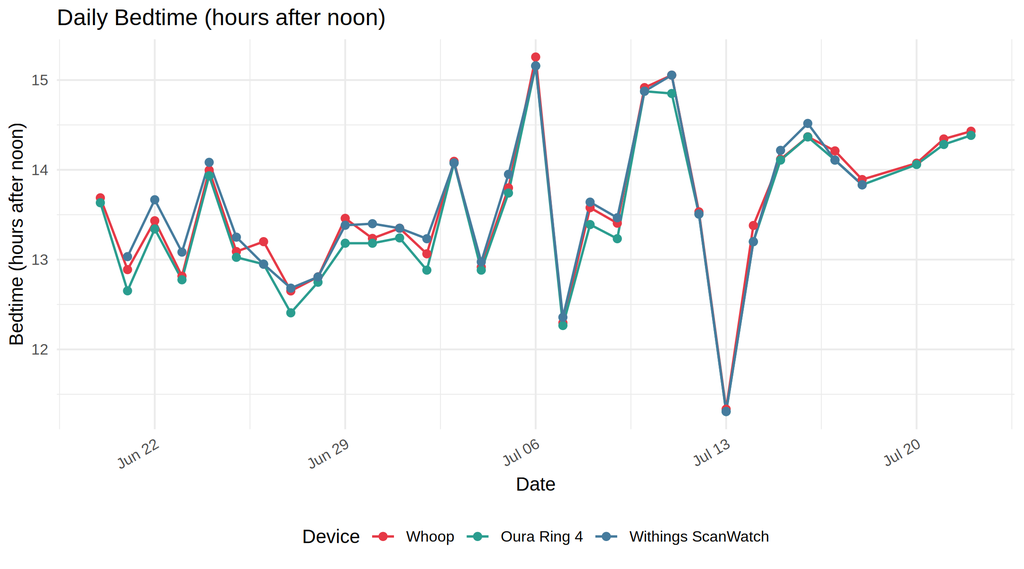

Bedtime by device across the study window. The three series sit almost on top of each other.

```r
plot_timeseries(long_df, "bedtime_hr")
```

## 10 Do the brands agree on how you are doing?

**What this section answers:** *Whoop’s Recovery score and Oura’s Readiness score both claim to summarise daily readiness on a 0–100 scale. Do they agree?*

This is the number most people actually look at each morning, and it is the sharpest test in the report: both brands take similar raw inputs (resting HR, HRV, sleep) and reduce them to one score.

**Show code that compares Whoop Recovery with Oura Readiness**

```r
readiness_agree <- run_all_agreement(wide_df, metrics = "readiness")
if (!is.null(readiness_agree)) {
  knitr::kable(
    readiness_agree |>
      dplyr::mutate(
        metric = "Readiness / Recovery score",
        dplyr::across(where(is.numeric), ~ round(.x, 3))
      ) |>
      dplyr::select(metric, device_a, device_b, n, pearson_r, spearman_rho,
                    mean_bias, loa_lower, loa_upper, icc, ba_trend_r, ba_trend_p),
    caption = "Whoop Recovery score vs Oura Readiness score"
  )
}
```

Whoop Recovery score vs Oura Readiness score

| metric | device_a | device_b | n | pearson_r | spearman_rho | mean_bias | loa_lower | loa_upper | icc | ba_trend_r | ba_trend_p |
| --- | --- | --- | --- | --- | --- | --- | --- | --- | --- | --- | --- |
| Readiness / Recovery score | Whoop | Oura Ring 4 | 32 | 0.239 | 0.224 | 12.25 | -25.211 | 49.711 | 0.103 | -0.828 | 0 |

**Show code that plots the readiness comparison**

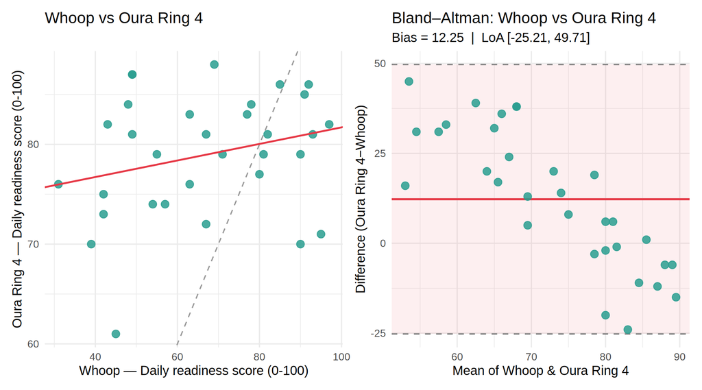

Whoop Recovery vs Oura Readiness. Wide scatter around the diagonal and a sloped Bland-Altman pattern show the two scores are not measuring the same thing.

```r
r_plots <- list(
  plot_scatter_pair(wide_df, "readiness", "whoop", "oura", "Whoop", "Oura Ring 4"),
  plot_bland_altman(wide_df, "readiness", "whoop", "oura", "Whoop", "Oura Ring 4")
)
patchwork::wrap_plots(Filter(Negate(is.null), r_plots), ncol = 2)
```

**The scores disagree far more than their inputs do.** Correlation is only about r = 0.24 — much weaker than the r > 0.9 the same two devices achieve on resting HR, HRV and sleep duration. There is also strong proportional bias: the gap between the scores depends on how high the score is, so no constant adjustment reconciles them.

The reason is that a readiness score is not a measurement — it is a *proprietary opinion* about the measurements, including each brand’s own baselining and weighting. Two devices can agree on your physiology and still disagree about what it means. Treat a readiness score as meaningful only within one brand, and never compare scores across brands.

## 11 Respiratory rate and sleep efficiency

**What this section answers:** *Do the devices agree on breathing rate during sleep and on sleep efficiency?*

- **Respiratory rate** = breaths per minute during sleep (typically 12–20 in healthy adults). Whoop and Oura only; Withings did not export it for 2026.
- **Sleep efficiency** = time asleep ÷ time in bed × 100. Above 85% is generally considered good.

**Show code that compares respiratory rate and sleep efficiency**

```r
re_agree <- run_all_agreement(wide_df, metrics = c("resp_rate", "sleep_eff"))
if (!is.null(re_agree)) {
  knitr::kable(
    re_agree |>
      dplyr::mutate(
        metric = METRIC_LABELS[metric],
        dplyr::across(where(is.numeric), ~ round(.x, 3))
      ) |>
      dplyr::select(metric, device_a, device_b, n, pearson_r, mean_bias,
                    loa_lower, loa_upper, icc, equivalent),
    caption = "Respiratory rate and sleep efficiency agreement"
  )
}
```

Respiratory rate and sleep efficiency agreement

| metric | device_a | device_b | n | pearson_r | mean_bias | loa_lower | loa_upper | icc | equivalent |
| --- | --- | --- | --- | --- | --- | --- | --- | --- | --- |
| Respiratory rate (breaths/min) | Whoop | Oura Ring 4 | 32 | 0.849 | 0.191 | -0.176 | 0.557 | 0.722 | Yes |
| Sleep efficiency (%) | Whoop | Oura Ring 4 | 32 | 0.403 | 1.469 | -5.932 | 8.869 | 0.369 | Yes |
| Sleep efficiency (%) | Whoop | Withings ScanWatch | 28 | 0.117 | 5.177 | -11.896 | 22.250 | 0.065 | No |
| Sleep efficiency (%) | Oura Ring 4 | Withings ScanWatch | 28 | 0.302 | 3.570 | -12.130 | 19.270 | 0.173 | No |

Respiratory rate agrees well (r = 0.85) and is the rare metric that also **passes the equivalence check** — the two devices differ by only about 0.2 breaths per minute. It is a slow, stable signal, and comparatively easy to measure.

Sleep efficiency is the mirror image, and a useful warning. Whoop and Oura also pass the equivalence check on it — their average difference is a mere 1.5 percentage points — yet they correlate at only r = 0.40. In other words the two devices produce the same *typical* efficiency while disagreeing about *which nights* were efficient. That combination is exactly why this report never relies on a single statistic: a small bias alone would have made this look like agreement.

## 12 Robustness checks

### 12.1 Does removing suspicious days change anything?

**What this section answers:** *Are the conclusions driven by a handful of bad days?*

The headline analysis is re-run twice: once on all data (`full`) and once excluding QC-flagged days (`clean`). Similar values in both rows mean the conclusions are robust.

**Show code that re-runs agreement with and without flagged days**

```r
if (!is.null(sensitivity)) {
  sens_display <- sensitivity |>
    dplyr::filter(metric %in% METRICS) |>
    dplyr::mutate(metric = METRIC_LABELS[metric],
                  dplyr::across(where(is.numeric), ~ round(.x, 3))) |>
    dplyr::select(sample, metric, device_a, device_b, n, pearson_r, mean_bias, mae)
  knitr::kable(sens_display, caption = "Agreement: full sample vs QC-cleaned sample")
}
```

Agreement: full sample vs QC-cleaned sample

| sample | metric | device_a | device_b | n | pearson_r | mean_bias | mae |
| --- | --- | --- | --- | --- | --- | --- | --- |
| full | Resting heart rate (bpm) | Whoop | Oura Ring 4 | 32 | 0.914 | 1.598 | 1.598 |
| full | Resting heart rate (bpm) | Whoop | Withings ScanWatch | 28 | 0.831 | 1.750 | 1.750 |
| full | Resting heart rate (bpm) | Oura Ring 4 | Withings ScanWatch | 28 | 0.814 | 0.185 | 0.755 |
| full | Heart rate variability (ms) | Whoop | Oura Ring 4 | 32 | 0.909 | -5.062 | 5.062 |
| full | Sleep duration (min) | Whoop | Oura Ring 4 | 32 | 0.965 | 18.625 | 19.344 |
| full | Sleep duration (min) | Whoop | Withings ScanWatch | 28 | 0.767 | 48.143 | 48.143 |
| full | Sleep duration (min) | Oura Ring 4 | Withings ScanWatch | 28 | 0.785 | 28.964 | 28.964 |
| full | Daily steps | Whoop | Oura Ring 4 | 28 | 0.996 | 89.571 | 211.929 |
| full | Daily steps | Whoop | Withings ScanWatch | 25 | 0.785 | 1535.320 | 1766.840 |
| full | Daily steps | Oura Ring 4 | Withings ScanWatch | 29 | 0.794 | 1321.759 | 1509.759 |
| clean | Resting heart rate (bpm) | Whoop | Oura Ring 4 | 32 | 0.914 | 1.598 | 1.598 |
| clean | Resting heart rate (bpm) | Whoop | Withings ScanWatch | 28 | 0.831 | 1.750 | 1.750 |
| clean | Resting heart rate (bpm) | Oura Ring 4 | Withings ScanWatch | 28 | 0.814 | 0.185 | 0.755 |
| clean | Heart rate variability (ms) | Whoop | Oura Ring 4 | 32 | 0.909 | -5.062 | 5.062 |
| clean | Sleep duration (min) | Whoop | Oura Ring 4 | 32 | 0.965 | 18.625 | 19.344 |
| clean | Sleep duration (min) | Whoop | Withings ScanWatch | 28 | 0.767 | 48.143 | 48.143 |
| clean | Sleep duration (min) | Oura Ring 4 | Withings ScanWatch | 28 | 0.785 | 28.964 | 28.964 |
| clean | Daily steps | Whoop | Oura Ring 4 | 10 | 0.979 | 102.200 | 211.000 |
| clean | Daily steps | Whoop | Withings ScanWatch | 7 | 0.904 | 2188.857 | 2188.857 |
| clean | Daily steps | Oura Ring 4 | Withings ScanWatch | 9 | 0.920 | 1564.000 | 1635.778 |

### 12.2 Does each device measure coherently on its own?

**What this section answers:** *Independent of cross-device agreement, does each device behave the way physiology says it should?*

Lower resting HR and higher HRV tend to occur on the same well-recovered days. A **negative** correlation within each device is therefore expected, and finding it confirms the device is internally consistent — a useful check for a device that disagrees with the others, since it separates “measuring something different” from “measuring nothing”.

**Show code that correlates RHR with HRV within each device**

```r
cross_rhr_hrv <- cross_metric_correlation(long_df, "rhr", "hrv")
if (!is.null(cross_rhr_hrv)) {
  knitr::kable(
    cross_rhr_hrv |> dplyr::mutate(dplyr::across(where(is.numeric), ~ round(.x, 3))),
    caption = "Within-device Spearman correlation: resting HR vs HRV"
  )
}
```

Within-device Spearman correlation: resting HR vs HRV

| device | metric_x | metric_y | n | spearman_rho | p_value |
| --- | --- | --- | --- | --- | --- |
| Whoop | rhr | hrv | 32 | -0.504 | 0.003 |
| Oura Ring 4 | rhr | hrv | 32 | -0.494 | 0.004 |

## 13 What this means in practice

- **Pick one device and stay with it.** Trends within a single device are trustworthy; absolute numbers are not transferable between devices. Switching devices mid-tracking breaks the continuity of your history.
- **Trust trends far more than single days.** Compare a daily change against the `srd` column: for sleep duration the smallest real difference approaches an hour, so a 20-minute change means nothing.
- **Sleep stage numbers deserve the most skepticism**, especially from Withings, whose deep/REM split differs so much that it is effectively a different measurement.
- **Never compare readiness or recovery scores across brands.** They agree less than any raw metric measured here.
- **Match definitions before concluding a device is wrong.** The apparent resting-HR failure was largely a “lowest versus average” mismatch, not a bad sensor — and correcting it revealed Oura and Withings to be nearly interchangeable.
- **Bedtime is the metric to trust if you need cross-device consistency**; sleep staging is the one to trust least.

## 14 Limitations

- **One participant, 33 days.** Every result is exploratory and cannot be generalized to other people or longer periods.
- **No ground truth.** Without polysomnography for sleep or ECG for heart rate, we can measure *agreement* but never *accuracy*. When devices disagree, this analysis cannot say which one is right.
- **Whoop steps were typed by hand** into a text note rather than exported, so that comparison is the least reliable in the report.
- **Withings exported no HRV** for 2026, so HRV is a two-device comparison only.
- **Withings sleep stops after July 18**, reducing the day count for every sleep comparison involving it.
- **Whoop and Oura are the only pair with near-complete overlap**, so their agreement estimates rest on more days than the others.
- **Equivalence margins were chosen by judgement**, not from clinical guidelines. Different margins would change which pairs pass.
- **Multiple comparisons.** Many tests are run across many metrics; only the three-device post-hoc tests are corrected for it. Individual p-values near 0.05 should not be over-read.
- **Unused signals.** Skin temperature (Whoop absolute vs Oura deviation) and blood oxygen are exported on incompatible scales or too sparsely to compare here.
- **All timestamps** are interpreted in US Pacific time (`America/Los_Angeles`).

## 15 Appendix — session information